# Day 1: R basics

8/13/2021

## Motivation:

## Why programming/stats?

- Reduce human error in repetitive tasks
- Reach conclusions
- Effective visualizations
- Automatize!!

## Why programming/stats? - Examples

- Labels
- Apply repetitive tasks to large amounts of data

[figure not shown]

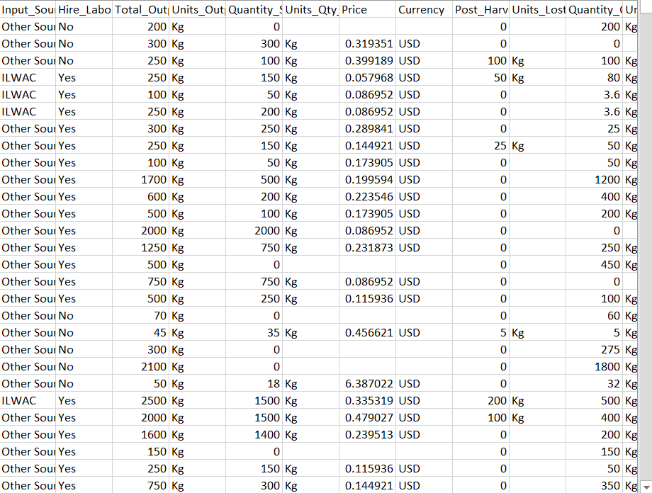

## R vs. RStudio

**R** is a programming language that is commonly used in research.  
**RStudio** is an interface  
More on R vs RStudio, [here](https://mgimond.github.io/ES218/R_vs_RStudio.html). More about RStudio [here](https://b-rodrigues.github.io/modern_R/getting-to-know-rstudio.html).

- switch to RStudio
- R script versus R markdown
- Good names for scripts:  
  `retrieve_data` = good / `retrieve data` = bad!

## Basic commands

## R is a calculator

```r
5+5
```

```
## [1] 10
```

```r
# 5+5
```

## Objects

```r
v1 <- 5 # create any type of object
v1 # now print it
```

```
## [1] 5
```

```r
v1 <- "five" # and overwrite it
# V1 != v1
```

## Naming objects

## Object classes

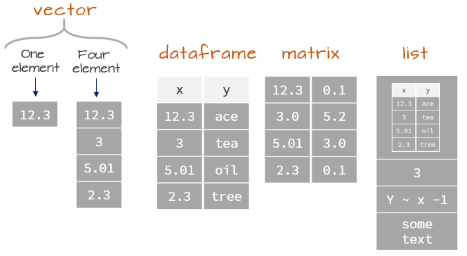

```r
knitr::include_graphics("figs/data_structures.png")
```

## How to read a function

## Packages

> An R package is a collection of functions, data, and documentation that extends the capabilities of base R.  
> [R4DS](https://r4ds.had.co.nz/introduction.html#r).  
> **TIDYVERSE** The packages in the tidyverse share a common philosophy of data and R programming, and are designed to work together naturally.

[**Why tidyverse?**](https://cran.r-project.org/web/packages/tidyverse/vignettes/manifesto.html)

## The pipe function `%>%`

Conventional:

```r
df1 <- read.csv("../data/tillage.csv") # https://doi.org/10.6084/m9.figshare.12155553

colnames(df1)
```

```
##  [1] "ï..Author"
##  [2] "Journal"
##  [3] "Year"
##  [4] "Site.country"
##  [5] "Location"
##  [6] "Latitude"
##  [7] "Longitude"
##  [8] "Soil.information.recorded.in.the.paper"
##  [9] "pH..surface.layer."
## [10] "Replications.in.experiment"
## [11] "Crop"
## [12] "Initial.year.of.NT.practice...or.first.year.of.experiment.if.missing."
## [13] "Sowing.year"
## [14] "Harvest.year"
## [15] "Years.since.NT.started..yrs."
```

[output cut: 38 more lines]

```r
df1 <- rename(df1,
              author= `ï..Author`,
              start = `Initial.year.of.NT.practice...or.first.year.of.experiment.if.missing.`)

df1 <- mutate(df1, difference = Yield.of.CT-Yield.of.NT)# ... etc
head(df1)
```

```
##         author                  Journal Year Site.country
## 1 Aase  et al. Soil & Tillage Research  1997          USA
## 2 Aase  et al. Soil & Tillage Research  1997          USA
## 3 Aase  et al. Soil & Tillage Research  1997          USA
## 4      Acharya  Soil & Tillage Research 2019          USA
## 5      Acharya  Soil & Tillage Research 2019          USA
## 6     Adimassu     Agricultural Systems 2019     Ethiopia
##                         Location Latitude Longitude
## 1                 Montana, Froid    48.28   -105.10
## 2                 Montana, Froid    48.28   -105.10
## 3                 Montana, Froid    48.28   -105.10
## 4        Bossier City, Louisiana    32.42    -93.64
## 5        Bossier City, Louisiana    32.42    -93.64
## 6 Awash River Basin, Addis Ababa     9.07     38.48
##   Soil.information.recorded.in.the.paper pH..surface.layer.
```

[output cut: 125 more lines]

## The pipe function - cont.

```r
library(tidyverse)
# again from scratch. What would happen otherwise?
df1 <- read.csv("../data/tillage.csv") # https://doi.org/10.6084/m9.figshare.12155553

df1 <- df1 %>%
  rename(author= `ï..Author`,
         start = `Initial.year.of.NT.practice...or.first.year.of.experiment.if.missing.`) %>%
  mutate(df1, difference = Yield.of.CT-Yield.of.NT)# ... etc

head(df1)
```

```
##         author                  Journal Year Site.country
## 1 Aase  et al. Soil & Tillage Research  1997          USA
## 2 Aase  et al. Soil & Tillage Research  1997          USA
## 3 Aase  et al. Soil & Tillage Research  1997          USA
## 4      Acharya  Soil & Tillage Research 2019          USA
## 5      Acharya  Soil & Tillage Research 2019          USA
## 6     Adimassu     Agricultural Systems 2019     Ethiopia
##                         Location Latitude Longitude
## 1                 Montana, Froid    48.28   -105.10
## 2                 Montana, Froid    48.28   -105.10
## 3                 Montana, Froid    48.28   -105.10
## 4        Bossier City, Louisiana    32.42    -93.64
## 5        Bossier City, Louisiana    32.42    -93.64
## 6 Awash River Basin, Addis Ababa     9.07     38.48
##   Soil.information.recorded.in.the.paper pH..surface.layer.
```

[output cut: 139 more lines]

## The tidyverse

Useful functions:

- `filter()`: selects ROWS that satisfty a logic test
- `arrange()`: reorders rows based on certain variables
- `select()`: selects COLUMNS. - **!** `dplyr::select()`.
- `mutate()`: creates a new column. Can overwrite preexisting columns. `.keep` = T/F
- `rename()`: renames columns
- `group_by()`: groups data based on levels of a variable. Subsequent functions will be treated for that group.

`group_by()`:

```r
usda <- read.csv("../data/USDAsurvey_00-18.csv")
usda %>% group_by(Year) %>% mutate(year_avg=mean(Value)) %>% head() # NAs
```

```
## # A tibble: 6 x 22
## # Groups:   Year [1]
##   Program  Year Period Week.Ending Geo.Level State State.ANSI Ag.District
##   <chr>   <int> <chr>  <lgl>       <chr>     <chr>      <int> <chr>
## 1 SURVEY   2018 YEAR   NA          COUNTY    ARKA~          5 EAST CENTR~
## 2 SURVEY   2018 YEAR   NA          COUNTY    ARKA~          5 EAST CENTR~
## 3 SURVEY   2018 YEAR   NA          COUNTY    ARKA~          5 EAST CENTR~
## 4 SURVEY   2018 YEAR   NA          COUNTY    ARKA~          5 EAST CENTR~
## 5 SURVEY   2018 YEAR   NA          COUNTY    ARKA~          5 EAST CENTR~
## 6 SURVEY   2018 YEAR   NA          COUNTY    ARKA~          5 EAST CENTR~
## # ... with 14 more variables: Ag.District.Code <int>, County <chr>,
## #   County.ANSI <int>, Zip.Code <lgl>, Region <lgl>, watershed_code <int>,
## #   Watershed <lgl>, Commodity <chr>, Data.Item <chr>, Domain <chr>,
## #   Domain.Category <chr>, Value <dbl>, CV.... <lgl>, year_avg <dbl>
```

- `summarise()`:

```r
usda %>% group_by(Year) %>% summarise(year_avg=mean(Value))
```

```
## # A tibble: 19 x 2
##     Year year_avg
##    <int>    <dbl>
##  1  2000     118.
##  2  2001     120.
##  3  2002     104.
##  4  2003     120.
##  5  2004     136.
##  6  2005     127.
##  7  2006     126.
##  8  2007     128.
##  9  2008     131.
## 10  2009     145.
## 11  2010     132.
## 12  2011     124.
## 13  2012     113.
## 14  2013     147.
## 15  2014     156.
## 16  2015     150.
## 17  2016     153.
## 18  2017     162.
## 19  2018     157.
```

## Good conding habits

- Object names

## Wrap up

- **Weekly Assignments**  
  ungraded, send me if you wish to receive feedback.
- **Individual project**  
  we will provide data  
  example
- [Join slack!](https://join.slack.com/t/ksucropsteam/shared_invite/zt-vgtjmo8y-gqZfijM_N0URJ4GdZmvUwQ)